# Study on Cars Fuel Consumption

Mansour Alhumaid

10/15/2020

In this study, a dataset of various cars will be explored and analysis will be made on fuel consumption on highways and city driving modes (using Miles per Gallon metrics, MPG) of different cars’ manufacturers, models, engine size, transmission type. MPG is simply the fuel economy of an car relates distance traveled and the amount of fuel consumed.

#### Analysis on Number of Cars of Different Manufacturers in the study

as start on the exploration process on the data, it is possible to list down all cars’ manufacturers counted in the study in order to have an idea about the variety of car manufacturers in this study

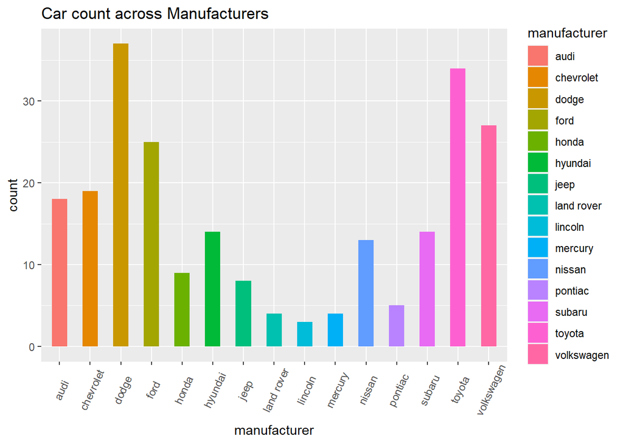

#### Analysis on number of cylinders among the cars

Here is an analysis of the number of cylinders counted for each car in the study group. Here, we notice a comparable range of 4, 6, and 8 cylinders which satisfy our need to have an equally representative sample for each cylinder type for studying the MPG later

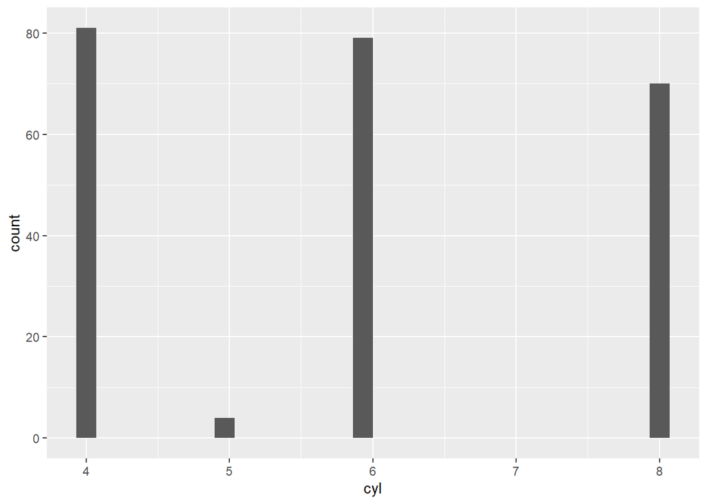

There are a few reasons that your car gets lower MPG in the city. First, it is because city driving is harder car than driving on the highway. This is because engine has to work harder to accelerate / decelerate more frequently when on city streets. This requires more gas, burns fuel faster, and therefore reduces gas mileage. On the other hand, highway driving requires maintaining a constant speed. Hence, acceleration is not changed considerably on highways which makes it easier on engine than city driving since engine has to do less work to maintain the speed car’s on highways. Therefore, it is compulsory to make a clear comparison between these two separate variables in our study.

fuel efficiency depends on transmission type. With a manual transmission, drivers use judgment to decide when the engine’s ready to move up or down through the gear, drivers make sure to stay in the most efficient range of revs and hence improving fuel efficiency

#### Analysis of Engine size of different classes of cars vs.Fuel Consumption (MPG) on Highways

When studying fuel consumption of cars, it is important to address the factor of engine size (i.e. displacement) and its correlation with fuel consumption as per below:

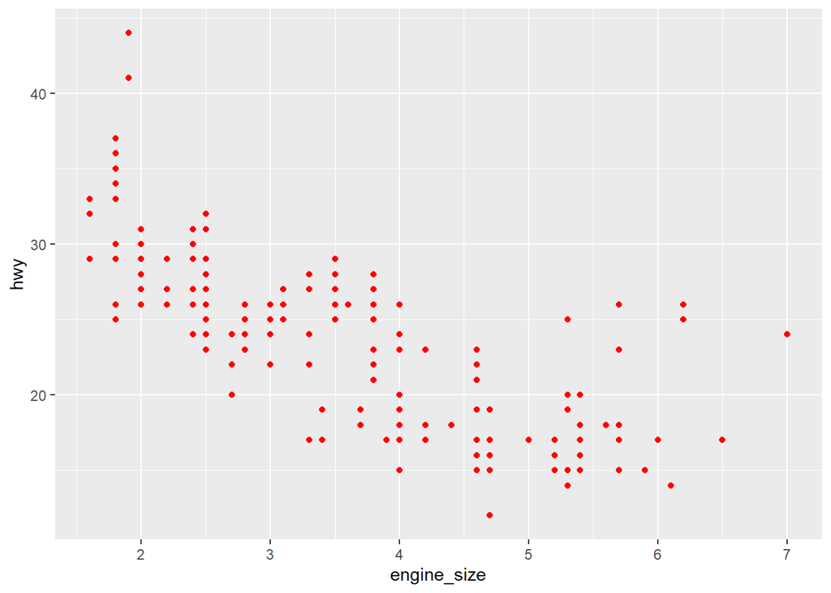

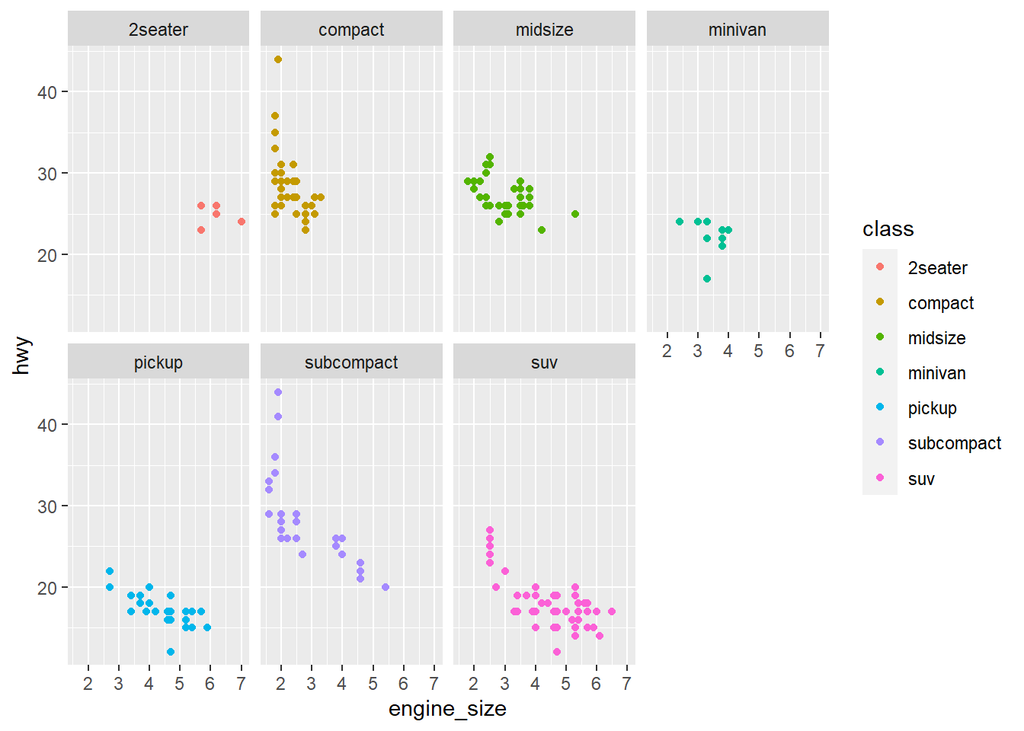

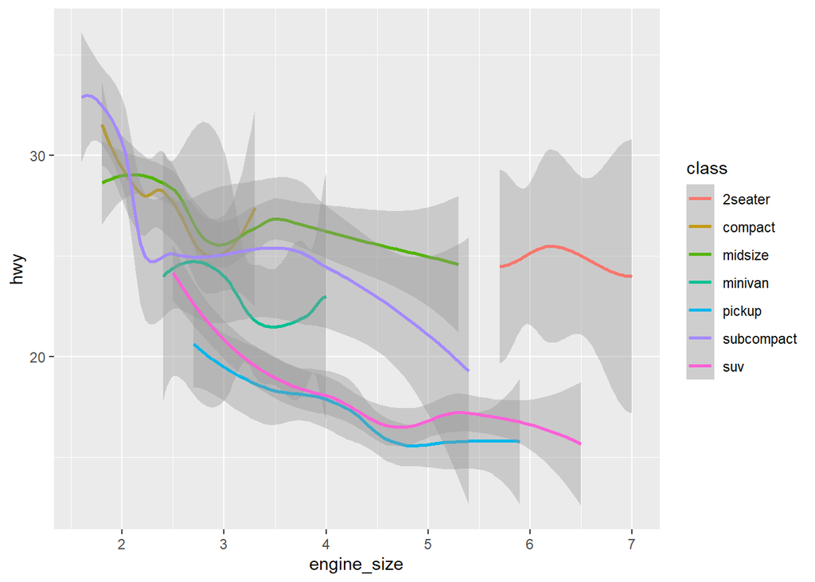